# xwMOOC 모형

고객이탈: 로지스틱 회귀모형 - `tidymodels`

이광춘

[Tidyverse Korea](https://www.facebook.com/groups/tidyverse/)

2020-12-29

# 1 고객이탈과 HR 이탈

고객이탈은 영어로 “Customer Churn” 혹은 “Customer Attrition”이라고 하는데 통상적으로 고객이 더이상 서비스 이용이나 제품구매를 멈출 때 발생된다. 거의 모든 사업영역에서 고객이탈이 문제가 되지만, 특히 문제가 되는 분야가 통신(텔코, Tele-communication)산업으로 KT, SKT, U+ 등 통신3사가 거의 과점을 하고 있는 산업분야로 이해하면 된다.

과거 고객이탈에 대한 부분만 관심을 가졌다는 현재는 인적자원(Human Resource) 임직원 이탈이 부각되고 있다.

- [Turnover costs way more than you think](https://www.huffingtonpost.com/julie-kantor/high-turnover-costs-way-more-than-you-think_b_9197238.html)
  1. The Cost of Training and On-Boarding
  2. Interview Expenses
  3. Advertising Costs
  4. Lowered Engagement
  5. Productivity of New Hires
  6. Impact on Morale & The Gossip Machine
  7. Less Effective Service
- [Employee turnover is the highest its been in 10 years. Here’s What To Do About It.](https://www.forbes.com/sites/jeffboss/2018/02/26/employee-turnover-is-the-highest-its-been-in-10-years-heres-what-to-do-about-it/)

인적자원 이탈을 두가지 형태로 나타난다.

- 자발적인 이직: 임직원이 사직하고 조직을 떠나는 경우.
  - 명목적인 이유
    - 더 나은 기회를 찾아 이직
    - 건강상의 이유
    - 업무전환배치와 근무지 변경
    - 교육
    - 개인적 사유 外
  - 숨겨진 이유
    - 상급자와 관계
    - 급여인상율
    - 초과근무
    - 업무상 출장 거리
    - 직무 만족도
    - 정년보장
- 비자발적인 이직: 조직이 임직원을 사직하게 되는 경우.

데이터가 다양해졌고 많이 축적되었기 때문에 과거에 비해 인적자원 및 고객이탈 대한 원인파악 및 대책 수립이 가능하게 되었다.

## 1.1 데이터셋

- 고객 이탈(Telco Customer Churn - Focused customer retention programs): https://www.kaggle.com/blastchar/telco-customer-churn/home
- 임직원 이탈(Employee Attrition - Can you forecast employee attrition?): https://www.kaggle.com/HRAnalyticRepository/employee-attrition-data/home

임직원 이탈에 대한 내용보다 고객이탈에 대한 내용을 중심을 설명가능한 예측모형을 만들어 나갑니다.

## 1.2 작업흐름도

원데이터에 대한 정제작업이 마무리되면 Information Value를 통해 변수 선택과 변수내 수준도 적절한 형태로 조정한 후에 로지스틱 선형회귀모형에 적합시킨다. 이 과정에서 VIF를 통해 중복되는 변수도 걸러내고 최종 모형을 만들어 성능평가를 한후에 모형에 대한 이해와 커뮤니케이션을 위한 정리작업을 수행한다.

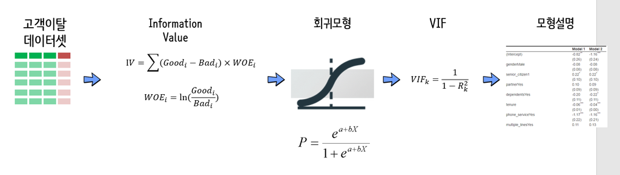

# 2 고객이탈 데이터 정제

`.csv` 데이터를 `read_csv()`를 통해 불러와서 변수명과 변수 자료형을 향수 분석에 맞게 조정한다.

```r
library(tidyverse)
library(readxl)
library(janitor)
library(skimr)

churn_dat <- read_csv("data/WA_Fn-UseC_-Telco-Customer-Churn.csv")

churn_df <- churn_dat %>%
  clean_names()

churn_list <- skim_to_list(churn_df)

churn_df <- churn_df %>%
  mutate(churn = factor(churn, levels = c("No", "Yes"))) %>%
  mutate_at(vars(churn_list$character$variable), as.factor) %>%
  mutate(senior_citizen = factor(senior_citizen)) %>%
  select(-customer_id) %>%
  mutate(multiple_lines    = ifelse(str_detect(multiple_lines, "No"), "No", "Yes"),
         internet_service  = ifelse(str_detect(internet_service, "No"), "No", "Yes"),
         online_security   = ifelse(str_detect(online_security, "No"), "No", "Yes"),
         online_backup     = ifelse(str_detect(online_backup, "No"), "No", "Yes"),
         device_protection = ifelse(str_detect(device_protection, "No"), "No", "Yes"),
         tech_support      = ifelse(str_detect(tech_support, "No"), "No", "Yes"),
         streaming_tv      = ifelse(str_detect(streaming_tv, "No"), "No", "Yes"),
         streaming_movies  = ifelse(str_detect(streaming_movies, "No"), "No", "Yes"))
```

## 2.1 고객 이탈 통계

먼저 고객 이탈에 대한 통계를 산출한다. 이를 위해서 문자형을 정수형으로 변환하고 이탈은 `1` 잔존을 `0`으로 인코딩한 후에 `mean()` 함수로 평균을 낸다.

```r
churn_df %>%
  summarise(churn_rate = mean(as.integer(churn)-1))
```

```
# A tibble: 1 x 1
  churn_rate
       <dbl>
1      0.265
```

## 2.2 고객이탈 시각화 - 연속형

`skimr` 팩키지 `skim_to_list()` 함수를 사용해서 변수 자료형을 문자형, 정수형, 숫자형, 부울형 등올 나눈후에 숫자형만 추출하여 이를 이탈목적변수(`churn`)와 교차하여 시각화한다.

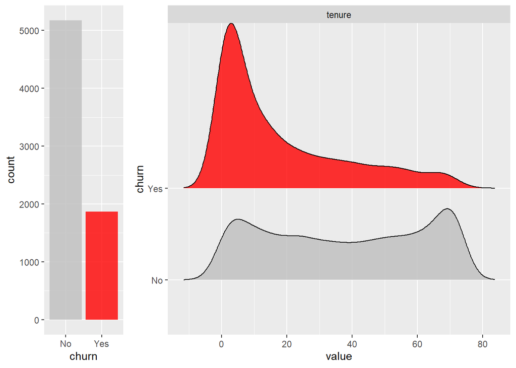

```r
library(ggridges)
library(cowplot)
## 2.1. 정적 시각화 -----
y_p <- churn_df %>%
    ggplot(aes(x = churn, fill = churn)) +
    geom_bar(alpha = 0.8) +
    scale_fill_manual(values = c("gray", "red")) +
    guides(fill = FALSE)

x_cont_p <- churn_df %>%
    select(churn, tenure, churn_list$numeric$variable) %>%
    gather(variable, value, -churn) %>%
    mutate(value = as.integer(value)) %>%
    ggplot(aes(x = value, y = churn, fill = churn)) +
    facet_wrap( ~ variable, scale = "free", ncol = 2) +
    scale_fill_manual(values = c("gray", "red")) +
    geom_density_ridges(alpha = 0.8) +
    guides(fill = FALSE, color = FALSE)

plot_grid(y_p, x_cont_p, rel_widths = c(1,3))
```

## 2.3 고객이탈 시각화 - 범주형

동일하게 `skimr` 팩키지 `skim_to_list()` 함수를 사용해서 변수 자료형을 문자형, 정수형, 숫자형, 부울형 등올 나눈후에 문자형을 요인(factor)형 변환한 후에 이를 이탈목적변수(`churn`)와 교차하여 시각화한다.

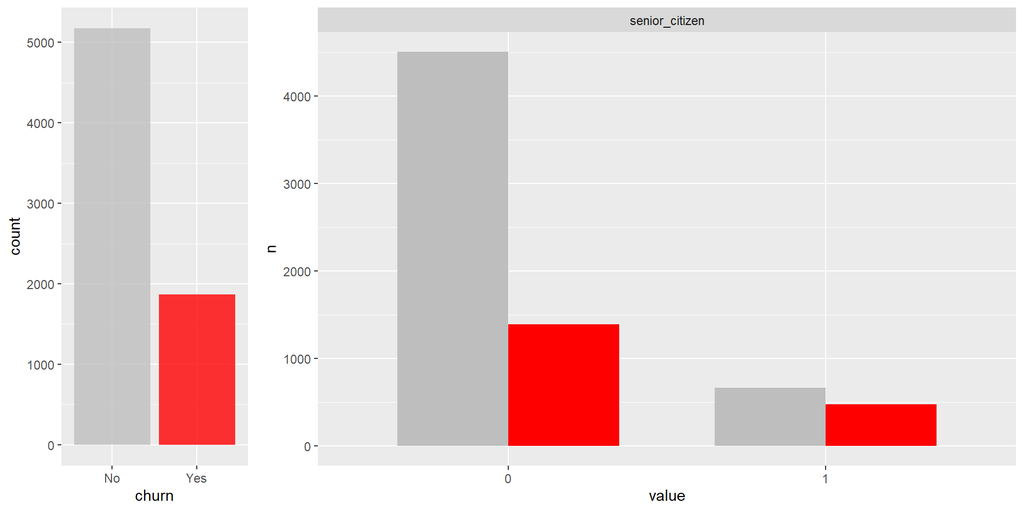

```r
x_cat_p <- churn_df %>%
    select_if(is.factor) %>%
    gather(variable, value, -churn) %>%
    group_by(churn) %>%
    count(variable, value) %>%
    ungroup() %>%
    ggplot(data = ., aes(x=value, y=n, fill=churn)) +
      geom_col(position="dodge", width=0.7) +
      facet_wrap(~variable, scale = "free", ncol = 4) +
      scale_fill_manual(values = c("gray", "red")) +
      guides(fill = FALSE, color = FALSE)

plot_grid(y_p, x_cat_p, rel_widths = c(1,3))
```

# 3 IV (information value)

`Information` 팩키지 `create_infotables()` 함수를 통해 IV를 쉽게 계산할 수 있다. 고객이탈에 영향을 많이 주는 변수를 예측변수를 사전에 선정하는데 참조한다.

| Information value | 예측력(Predictive power) |
| --- | --- |
| IV < 0.15 | Poor |
| 0.15 < IV < 0.4 | Moderate |
| IV > 0.4 | Strong |

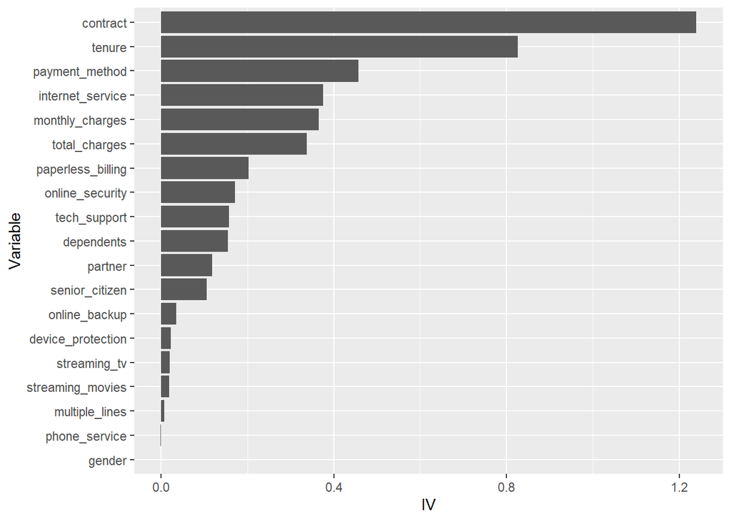

```r
library(Information) # install.packages("Information")

churn_iv_df <- churn_df %>%
  mutate(churn = as.integer(churn) -1 )

churn_iv <- create_infotables(data=churn_iv_df, y="churn", bins=10, parallel=TRUE)

churn_iv$Summary %>%
  mutate(Variable = fct_reorder(Variable, IV)) %>%
  ggplot(aes(x=Variable, y=IV)) +
    geom_col() +
    coord_flip()
```

```r
churn_iv$Summary %>%
  top_n(6, wt=IV)
```

```
          Variable        IV
1         contract 1.2385598
2           tenure 0.8262254
3   payment_method 0.4571089
4 internet_service 0.3751828
5  monthly_charges 0.3656368
6    total_charges 0.3373546
```

# 4 예측모형 생성[^1]

과거 `caret` 팩키지를 활용하여 훈련데이터와 검증데이터로 분리했다면, 이번에는 `tidymodels`를 구성하는 `parsnip` 팩키지를 활용하여 로지스틱 회귀모형을 구현한다.

## 4.1 훈련/시험 데이터 생성

먼저, 훈련/시험 데이터로 나눠 훈련데이터를 대상으로 고객이탈 예측모형을 개발한다. `initial_split()` 함수로 전체 데이터를 7:3으로 훈련/시험 데이터로 분리할 수 있다.

```r
library(tidymodels)

churn_tbl <- churn_df %>%
  mutate_if(is.character, as.factor) %>%
  drop_na()

set.seed(777)

splits <- initial_split(churn_tbl, prop = 0.7, strata = churn)

splits
```

```
<Analysis/Assess/Total>
<4924/2108/7032>
```

## 4.2 피처 공학

```r
recipe_spec <- recipe(churn ~ ., data = training(splits)) %>%
  step_other(all_nominal(), -all_outcomes()) %>%
  step_normalize(all_numeric())

# recipe_spec %>% prep() %>% juice()
```

## 4.3 예측모형 생성

| VIF | Interpretation |
| --- | --- |
| 1 < VIF | 상관관계 없음 |
| 1 < VIF < 5 | 다소 상관관계 존재함 |
| VIF > 5 | 심하게 상관관계 존재함 |

하지만, `tidymodels`로 바뀌게 되면 Feature Engineering은 `recipes`, 다양한 모형은 `parsnip`을 사용해서 정의하고 이를 `workflows`로 연결시키면 코드도 깔끔하고 나중에 유연하게 고성능 예측모형을 개발할 수 있게 된다.

```r
model_spec <- logistic_reg( mode = "classification") %>%
    set_engine("glm")

wkfl_fit <- workflows::workflow() %>%
  add_recipe(recipe_spec) %>%
  add_model(model_spec) %>%
  fit(training(splits))

wkfl_fit
```

```
== Workflow [trained] ==========================================================
Preprocessor: Recipe
Model: logistic_reg()

-- Preprocessor ----------------------------------------------------------------
2 Recipe Steps

* step_other()
* step_normalize()

-- Model -----------------------------------------------------------------------

Call:  stats::glm(formula = ..y ~ ., family = stats::binomial, data = data)

Coefficients:
                          (Intercept)                             genderMale
                             -0.06511                                0.02437
                      senior_citizen1                             partnerYes
                              0.23080                                0.02981
                        dependentsYes                                 tenure
                             -0.03450                               -1.40916
                     phone_serviceYes                      multiple_linesYes
                             -1.27111                                0.07666
                  internet_serviceYes                     online_securityYes
                              0.15628                               -0.37865
                     online_backupYes                   device_protectionYes
                             -0.38647                               -0.19659
                      tech_supportYes                        streaming_tvYes
                             -0.48495                               -0.08017
                  streaming_moviesYes                       contractOne year
                             -0.14768                               -0.70626
                     contractTwo year                   paperless_billingYes
                             -1.37344                                0.35043
payment_methodCredit card (automatic)         payment_methodElectronic check
                             -0.16168                                0.34069
           payment_methodMailed check                        monthly_charges
                             -0.09263                                0.91578
                        total_charges
                              0.62213

Degrees of Freedom: 4923 Total (i.e. Null);  4901 Residual
Null Deviance:      5703
Residual Deviance: 4047     AIC: 4093
```

## 4.4 예측모형 성능

`workflow` 객체를 `predict()` 함수에 넣어 시험데이터를 대상으로 고객이탈 여부와 확률을 산출하여 이를 데이터프레임으로 저장시킨다.

```r
prediction_class_test <- predict(wkfl_fit, new_data = testing(splits), type = "class")

prediction_prob_test  <- predict(wkfl_fit, new_data = testing(splits), type = "prob")

results_tbl <- bind_cols(
    prediction_class_test,
    prediction_prob_test,
    testing(splits)
)
```

고객이탈 분류기 성능을 `roc_auc()` 함수로 추정할 수 있고, `autoplot()` 함수로 시각적으로 확이도 가능하다.

```r
results_tbl %>%
    roc_auc(churn, .pred_Yes )
```

```
# A tibble: 1 x 3
  .metric .estimator .estimate
  <chr>   <chr>          <dbl>
1 roc_auc binary         0.836
```

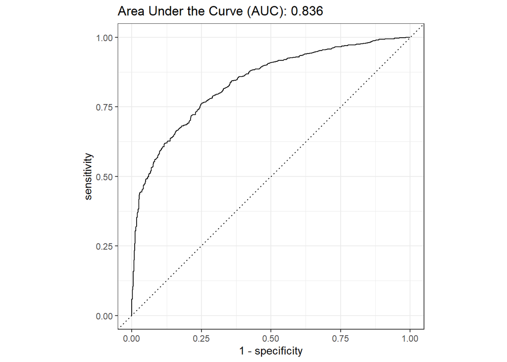

```r
results_tbl %>%
    roc_curve(churn, .pred_Yes ) %>%
    autoplot(
        options = list(
            smooth = TRUE
        )
    ) +
    labs(title = "Area Under the Curve (AUC): 0.836")
```

# 5 예측모형 설명

## 5.1 중요 변수

`workflow` 객체로부터 `parsnip` 객체를 뽑아내서 이를 `vip()` 함수에 넣어준다. 이를 통해, 중요변수로 `tenure`, `monthly_charges`를 확인할 수 있다.

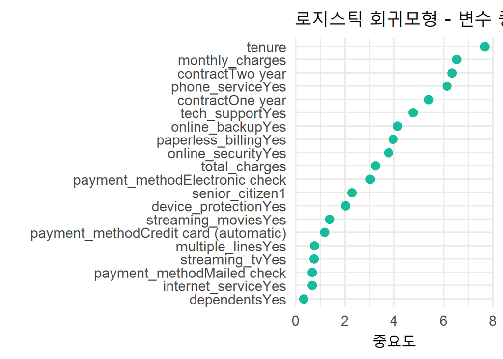

```r
library(vip)

# 중요변수 시각화
wkfl_fit$fit$fit %>%
    vip(
        num_features = 20,
        geom         = "point",
        aesthetics   = list(
            size     = 4,
            color    = "#18bc9c"
        )
    ) +
    theme_minimal(base_size = 18) +
    labs(title = "로지스틱 회귀모형 - 변수 중요도",
         y="중요도")
```

## 5.2 고객 이탈 설명

중요변수로 `tenure`, `monthly_charges`를 고객이탈야부를 교차시켜 시각화한다. 월별 통신료가 높은 고객의 이탈율이 상대적으로 초기에 높은 것이 확인된다.

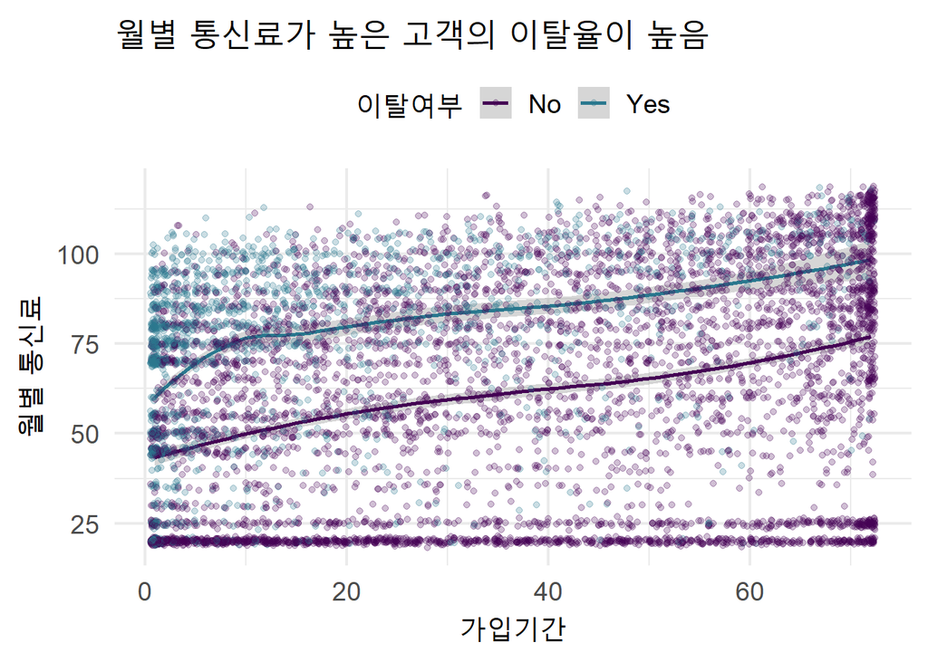

```r
churn_tbl %>%
    ggplot(aes(tenure, monthly_charges, color = churn)) +
    geom_smooth(method = "loess") +
    geom_jitter(alpha = 0.25) +
    theme_minimal(base_size = 18) +
    scale_color_viridis_d(end = 0.4) +
    labs(title = "월별 통신료가 높은 고객의 이탈율이 높음",
         x     = "가입기간",
         y     = "월별 통신료",
         color = "이탈여부") +
    theme(legend.position = "top")
```

# 6 예측모형 활용

예측모형 성능을 확인한 후에 가장 이탈 위험이 많은 고객 상위 10을 뽑아 이를 다음 후속작업에 활용한다. `tidypredict` 팩키지 `tidypredict_to_column()` 함수를 사용하면 깔끔하게 이탈확률이 높은 고객을 추려내는데 도움이 되는데, 따로 팩키지를 사용하지 말고 앞서 제작한 `results_tbl` 데이터프레임에 모든 정보가 담겨있어 이를 활용하여 이탈위험이 높은 고객 10명을 추려낸다.

```r
results_tbl %>%
  select(-.pred_No) %>%
  top_n(10, wt=.pred_Yes) %>%
  DT::datatable() %>%
    DT::formatPercentage(".pred_Yes", digits=1)
```

|  | .pred_class | .pred_Yes | gender | senior_citizen | partner | dependents | tenure | phone_service | multiple_lines | internet_service | online_security | online_backup | device_protection | tech_support | streaming_tv | streaming_movies | contract | paperless_billing | payment_method | monthly_charges | total_charges | churn |
| --- | --- | --- | --- | --- | --- | --- | --- | --- | --- | --- | --- | --- | --- | --- | --- | --- | --- | --- | --- | --- | --- | --- |
| 1 | Yes | 0.836293251989609 | Female | 1 | No | No | 4 | Yes | Yes | Yes | No | No | No | No | Yes | Yes | Month-to-month | Yes | Electronic check | 95.45 | 396.1 | Yes |
| 2 | Yes | 0.818076851674695 | Male | 1 | No | No | 8 | Yes | Yes | Yes | No | No | Yes | No | Yes | Yes | Month-to-month | Yes | Electronic check | 100.6 | 819.4 | Yes |
| 3 | Yes | 0.810110037509838 | Female | 0 | No | No | 2 | Yes | Yes | Yes | No | No | No | No | Yes | Yes | Month-to-month | Yes | Electronic check | 95.15 | 196.9 | Yes |
| 4 | Yes | 0.816150440989971 | Male | 1 | No | No | 1 | Yes | Yes | Yes | No | No | Yes | No | Yes | No | Month-to-month | Yes | Electronic check | 88.8 | 88.8 | Yes |
| 5 | Yes | 0.819866307537527 | Female | 1 | No | No | 1 | Yes | No | Yes | No | No | No | No | Yes | Yes | Month-to-month | Yes | Electronic check | 91.3 | 91.3 | Yes |
| 6 | Yes | 0.818585586159396 | Male | 1 | Yes | No | 7 | Yes | Yes | Yes | No | No | Yes | No | Yes | Yes | Month-to-month | Yes | Electronic check | 99.25 | 665.45 | Yes |
| 7 | Yes | 0.836453614618304 | Male | 1 | Yes | No | 1 | Yes | Yes | Yes | No | No | No | No | Yes | No | Month-to-month | Yes | Electronic check | 86.05 | 86.05 | Yes |
| 8 | Yes | 0.822477176425922 | Female | 1 | No | No | 2 | Yes | Yes | Yes | No | No | No | No | Yes | No | Month-to-month | Yes | Electronic check | 85.55 | 187.45 | Yes |
| 9 | Yes | 0.842597152702256 | Male | 1 | No | No | 3 | Yes | Yes | Yes | No | No | No | No | Yes | Yes | Month-to-month | Yes | Electronic check | 94.85 | 335.75 | No |
| 10 | Yes | 0.845499772333644 | Male | 1 | No | No | 1 | Yes | Yes | Yes | No | No | No | No | Yes | Yes | Month-to-month | Yes | Electronic check | 94 | 94 | Yes |

# 7 예측모형 커뮤니케이션

`texreg` 팩키지 혹은 `stargazer` 팩키지를 통해 예측모형에 대한 사항을 정리하여 커뮤니케이션하기 용이하다. 마찬가지로 `workflow` 객체에서 `parsnip` 객체를 추출한다.

```r
library(texreg)

# screenreg(list(churn_glm, best_glm), custom.note = "")
# htmlreg(list(churn_glm, best_glm), custom.note = "")

htmlreg(wkfl_fit$fit$fit, custom.note = "")
```

Statistical models

|  | Model 1 |
| --- | --- |
| (Intercept) | -0.07 |
|  | (0.42) |
| genderMale | 0.02 |
|  | (0.08) |
| senior_citizen1 | 0.23* |
|  | (0.10) |
| partnerYes | 0.03 |
|  | (0.09) |
| dependentsYes | -0.03 |
|  | (0.11) |
| tenure | -1.41*** |
|  | (0.18) |
| phone_serviceYes | -1.27*** |
|  | (0.21) |
| multiple_linesYes | 0.08 |
|  | (0.10) |
| internet_serviceYes | 0.16 |
|  | (0.24) |
| online_securityYes | -0.38*** |
|  | (0.10) |
| online_backupYes | -0.39*** |
|  | (0.09) |
| device_protectionYes | -0.20* |
|  | (0.10) |
| tech_supportYes | -0.48*** |
|  | (0.10) |
| streaming_tvYes | -0.08 |
|  | (0.11) |
| streaming_moviesYes | -0.15 |
|  | (0.11) |
| contractOne year | -0.71*** |
|  | (0.13) |
| contractTwo year | -1.37*** |
|  | (0.22) |
| paperless_billingYes | 0.35*** |
|  | (0.09) |
| payment_methodCredit card (automatic) | -0.16 |
|  | (0.14) |
| payment_methodElectronic check | 0.34** |
|  | (0.11) |
| payment_methodMailed check | -0.09 |
|  | (0.14) |
| monthly_charges | 0.92*** |
|  | (0.14) |
| total_charges | 0.62** |
|  | (0.19) |
| Deviance (Null) | 5702.76 |
| df.null | 4923 |
| Log Likelihood | -2023.75 |
| AIC | 4093.49 |
| BIC | 4243.03 |
| Deviance | 4047.49 |
| DF Resid. | 4901 |

[^1]: [Matt Dancho (2020-12-15), “Logistic Regression in R | R-Tip 015”, Business Science](https://www.youtube.com/watch?v=Qi-sVE0SWFc)

데이터 과학자 [이광춘](https://github.com/statkclee/) 저작

*kwangchun.lee.7@gmail.com*